# Risk Factor Analysis

## Outcome Variable

**Outcome Variable:** y_rate_len

## Predictor Variables

**Intervention Variable:** exclfeed3

**Adjustment Set:**

- arm
- sex
- W_mage
- meducyrs
- feducyrs
- hhwealth_quart
- hfoodsec
- W_mhtcm
- vagbrth
- W_gagebrth
- W_birthwt
- W_birthlen
- W_nrooms
- W_nchldlt5
- month
- brthmon
- W_parity
- impfloor
- impsan
- safeh20
- delta_W_mage
- delta_meducyrs
- delta_feducyrs
- delta_hhwealth_quart
- delta_hfoodsec
- delta_W_mhtcm
- delta_vagbrth
- delta_W_gagebrth
- delta_W_birthwt
- delta_W_birthlen
- delta_W_nrooms
- delta_W_nchldlt5
- delta_month
- delta_brthmon
- delta_W_parity
- delta_impfloor
- delta_impsan
- delta_safeh20

## Stratifying Variables

The analysis was stratified on these variable(s):

- agecat
- studyid
- country

## Data Summary

| agecat | studyid | country | exclfeed3 | n_cell | n |
| --- | --- | --- | --- | --- | --- |
| 0-3 months | ki0047075b-MAL-ED | BANGLADESH | 0 | 66 | 239 |
| 0-3 months | ki0047075b-MAL-ED | BANGLADESH | 1 | 173 | 239 |
| 0-3 months | ki0047075b-MAL-ED | BRAZIL | 0 | 113 | 180 |
| 0-3 months | ki0047075b-MAL-ED | BRAZIL | 1 | 67 | 180 |
| 0-3 months | ki0047075b-MAL-ED | INDIA | 0 | 77 | 199 |
| 0-3 months | ki0047075b-MAL-ED | INDIA | 1 | 122 | 199 |
| 0-3 months | ki0047075b-MAL-ED | NEPAL | 0 | 112 | 175 |
| 0-3 months | ki0047075b-MAL-ED | NEPAL | 1 | 63 | 175 |
| 0-3 months | ki0047075b-MAL-ED | PERU | 0 | 203 | 268 |
| 0-3 months | ki0047075b-MAL-ED | PERU | 1 | 65 | 268 |
| 0-3 months | ki0047075b-MAL-ED | SOUTH AFRICA | 0 | 195 | 226 |
| 0-3 months | ki0047075b-MAL-ED | SOUTH AFRICA | 1 | 31 | 226 |
| 0-3 months | ki0047075b-MAL-ED | TANZANIA, UNITED REPUBLIC OF | 0 | 164 | 224 |
| 0-3 months | ki0047075b-MAL-ED | TANZANIA, UNITED REPUBLIC OF | 1 | 60 | 224 |
| 0-3 months | ki1000108-CMC-V-BCS-2002 | INDIA | 0 | 0 | 4 |
| 0-3 months | ki1000108-CMC-V-BCS-2002 | INDIA | 1 | 4 | 4 |
| 0-3 months | ki1000108-IRC | INDIA | 0 | 10 | 10 |
| 0-3 months | ki1000108-IRC | INDIA | 1 | 0 | 10 |
| 0-3 months | ki1000109-EE | PAKISTAN | 0 | 32 | 592 |
| 0-3 months | ki1000109-EE | PAKISTAN | 1 | 560 | 592 |
| 0-3 months | ki1000304b-SAS-CompFeed | INDIA | 0 | 19 | 398 |
| 0-3 months | ki1000304b-SAS-CompFeed | INDIA | 1 | 379 | 398 |
| 0-3 months | ki1017093b-PROVIDE | BANGLADESH | 0 | 188 | 634 |
| 0-3 months | ki1017093b-PROVIDE | BANGLADESH | 1 | 446 | 634 |
| 0-3 months | ki1101329-Keneba | GAMBIA | 0 | 151 | 1175 |
| 0-3 months | ki1101329-Keneba | GAMBIA | 1 | 1024 | 1175 |
| 0-3 months | kiGH5241-JiVitA-3 | BANGLADESH | 0 | 4260 | 39314 |
| 0-3 months | kiGH5241-JiVitA-3 | BANGLADESH | 1 | 35054 | 39314 |
| 0-3 months | kiGH5241-JiVitA-4 | BANGLADESH | 0 | 20 | 242 |
| 0-3 months | kiGH5241-JiVitA-4 | BANGLADESH | 1 | 222 | 242 |

[output cut: 92 more lines]

The following strata were considered:

- agecat: 0-3 months, studyid: ki0047075b-MAL-ED, country: BANGLADESH
- agecat: 0-3 months, studyid: ki0047075b-MAL-ED, country: BRAZIL
- agecat: 0-3 months, studyid: ki0047075b-MAL-ED, country: INDIA
- agecat: 0-3 months, studyid: ki0047075b-MAL-ED, country: NEPAL
- agecat: 0-3 months, studyid: ki0047075b-MAL-ED, country: PERU
- agecat: 0-3 months, studyid: ki0047075b-MAL-ED, country: SOUTH AFRICA
- agecat: 0-3 months, studyid: ki0047075b-MAL-ED, country: TANZANIA, UNITED REPUBLIC OF
- agecat: 0-3 months, studyid: ki1000108-CMC-V-BCS-2002, country: INDIA
- agecat: 0-3 months, studyid: ki1000108-IRC, country: INDIA
- agecat: 0-3 months, studyid: ki1000109-EE, country: PAKISTAN
- agecat: 0-3 months, studyid: ki1000304b-SAS-CompFeed, country: INDIA
- agecat: 0-3 months, studyid: ki1017093b-PROVIDE, country: BANGLADESH
- agecat: 0-3 months, studyid: ki1101329-Keneba, country: GAMBIA
- agecat: 0-3 months, studyid: kiGH5241-JiVitA-3, country: BANGLADESH
- agecat: 0-3 months, studyid: kiGH5241-JiVitA-4, country: BANGLADESH
- agecat: 12-24 months, studyid: ki0047075b-MAL-ED, country: BANGLADESH
- agecat: 12-24 months, studyid: ki0047075b-MAL-ED, country: BRAZIL
- agecat: 12-24 months, studyid: ki0047075b-MAL-ED, country: INDIA
- agecat: 12-24 months, studyid: ki0047075b-MAL-ED, country: NEPAL
- agecat: 12-24 months, studyid: ki0047075b-MAL-ED, country: PERU
- agecat: 12-24 months, studyid: ki0047075b-MAL-ED, country: SOUTH AFRICA
- agecat: 12-24 months, studyid: ki0047075b-MAL-ED, country: TANZANIA, UNITED REPUBLIC OF
- agecat: 12-24 months, studyid: ki1000108-CMC-V-BCS-2002, country: INDIA
- agecat: 12-24 months, studyid: ki1000108-IRC, country: INDIA
- agecat: 12-24 months, studyid: ki1017093b-PROVIDE, country: BANGLADESH
- agecat: 12-24 months, studyid: ki1101329-Keneba, country: GAMBIA
- agecat: 12-24 months, studyid: ki1113344-GMS-Nepal, country: NEPAL
- agecat: 12-24 months, studyid: kiGH5241-JiVitA-3, country: BANGLADESH
- agecat: 12-24 months, studyid: kiGH5241-JiVitA-4, country: BANGLADESH
- agecat: 3-6 months, studyid: ki0047075b-MAL-ED, country: BANGLADESH
- agecat: 3-6 months, studyid: ki0047075b-MAL-ED, country: BRAZIL
- agecat: 3-6 months, studyid: ki0047075b-MAL-ED, country: INDIA
- agecat: 3-6 months, studyid: ki0047075b-MAL-ED, country: NEPAL
- agecat: 3-6 months, studyid: ki0047075b-MAL-ED, country: PERU
- agecat: 3-6 months, studyid: ki0047075b-MAL-ED, country: SOUTH AFRICA
- agecat: 3-6 months, studyid: ki0047075b-MAL-ED, country: TANZANIA, UNITED REPUBLIC OF
- agecat: 3-6 months, studyid: ki1000108-CMC-V-BCS-2002, country: INDIA
- agecat: 3-6 months, studyid: ki1000108-IRC, country: INDIA
- agecat: 3-6 months, studyid: ki1000109-EE, country: PAKISTAN
- agecat: 3-6 months, studyid: ki1000304b-SAS-CompFeed, country: INDIA
- agecat: 3-6 months, studyid: ki1017093b-PROVIDE, country: BANGLADESH
- agecat: 3-6 months, studyid: ki1101329-Keneba, country: GAMBIA
- agecat: 3-6 months, studyid: ki1113344-GMS-Nepal, country: NEPAL
- agecat: 3-6 months, studyid: kiGH5241-JiVitA-3, country: BANGLADESH
- agecat: 3-6 months, studyid: kiGH5241-JiVitA-4, country: BANGLADESH
- agecat: 6-12 months, studyid: ki0047075b-MAL-ED, country: BANGLADESH
- agecat: 6-12 months, studyid: ki0047075b-MAL-ED, country: BRAZIL
- agecat: 6-12 months, studyid: ki0047075b-MAL-ED, country: INDIA
- agecat: 6-12 months, studyid: ki0047075b-MAL-ED, country: NEPAL
- agecat: 6-12 months, studyid: ki0047075b-MAL-ED, country: PERU
- agecat: 6-12 months, studyid: ki0047075b-MAL-ED, country: SOUTH AFRICA
- agecat: 6-12 months, studyid: ki0047075b-MAL-ED, country: TANZANIA, UNITED REPUBLIC OF
- agecat: 6-12 months, studyid: ki1000108-CMC-V-BCS-2002, country: INDIA
- agecat: 6-12 months, studyid: ki1000108-IRC, country: INDIA
- agecat: 6-12 months, studyid: ki1000109-EE, country: PAKISTAN
- agecat: 6-12 months, studyid: ki1000304b-SAS-CompFeed, country: INDIA
- agecat: 6-12 months, studyid: ki1017093b-PROVIDE, country: BANGLADESH
- agecat: 6-12 months, studyid: ki1101329-Keneba, country: GAMBIA
- agecat: 6-12 months, studyid: ki1113344-GMS-Nepal, country: NEPAL
- agecat: 6-12 months, studyid: kiGH5241-JiVitA-3, country: BANGLADESH
- agecat: 6-12 months, studyid: kiGH5241-JiVitA-4, country: BANGLADESH

### Dropped Strata

Some strata were dropped due to rare outcomes:

- agecat: 0-3 months, studyid: ki1000108-CMC-V-BCS-2002, country: INDIA
- agecat: 0-3 months, studyid: ki1000108-IRC, country: INDIA
- agecat: 3-6 months, studyid: ki1000108-CMC-V-BCS-2002, country: INDIA
- agecat: 3-6 months, studyid: ki1000108-IRC, country: INDIA
- agecat: 3-6 months, studyid: kiGH5241-JiVitA-4, country: BANGLADESH
- agecat: 6-12 months, studyid: ki1000108-CMC-V-BCS-2002, country: INDIA
- agecat: 6-12 months, studyid: ki1000108-IRC, country: INDIA
- agecat: 6-12 months, studyid: ki1000109-EE, country: PAKISTAN
- agecat: 6-12 months, studyid: kiGH5241-JiVitA-4, country: BANGLADESH
- agecat: 12-24 months, studyid: ki1000108-CMC-V-BCS-2002, country: INDIA
- agecat: 12-24 months, studyid: ki1000108-IRC, country: INDIA

## Methods Detail

We’re interested in the causal parameters $E[Y_a]$ for all values of $a \in \mathcal{A}$. These parameters represent the mean outcome if, possibly contrary to fact, we intervened to set all units to have $A=a$. Under the randomization and positivity assumptions, these are identified by the statistical parameters $\psi_a=E_W[E_{Y|A,W}(Y|A=a,W)]$. In addition, we’re interested in the mean of $Y$, $E[Y]$ under no intervention (the observed mean). We will estimate these parameters by using SuperLearner to fit the relevant likelihood factors – $E_{Y|A,W}(Y|A=a,W)$ and $p(A=a|W)$, and then updating our likelihood fit using a joint TMLE.

For unadjusted analyses ($W=\{\}$), initial likelihoods were estimated using Lrnr_glm to estimate the simple $E(Y|A)$ and Lrnr_mean to estimate $p(A)$. For adjusted analyses, a small library containing Lrnr_glmnet, Lrnr_xgboost, and Lrnr_mean was used.

Having estimated these parameters, we will then use the delta method to estimate relative risks and attributable risks relative to a prespecified baseline level of $A$.

# Results Detail

## Results Plots

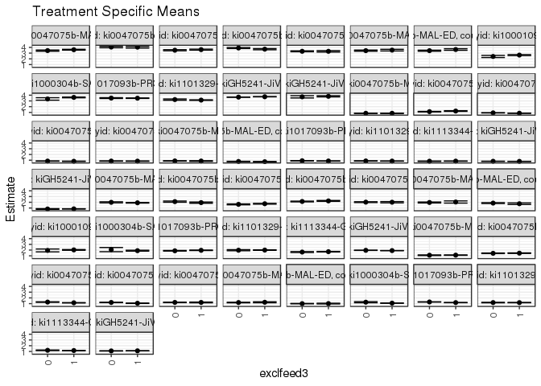

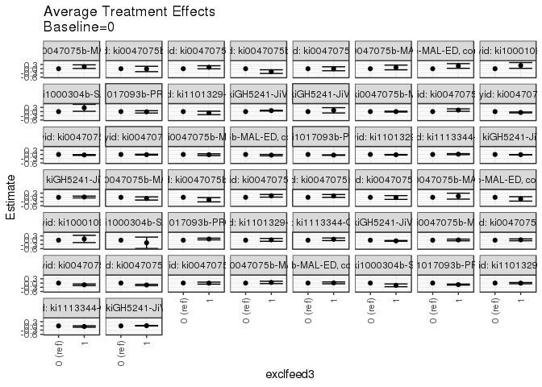

## Results Table

### Parameter: TSM

| agecat | studyid | country | intervention_level | baseline_level | estimate | ci_lower | ci_upper |
| --- | --- | --- | --- | --- | --- | --- | --- |
| 0-3 months | ki0047075b-MAL-ED | BANGLADESH | 0 | NA | 3.4408119 | 3.3334610 | 3.5481629 |
| 0-3 months | ki0047075b-MAL-ED | BANGLADESH | 1 | NA | 3.5892309 | 3.5151654 | 3.6632964 |
| 0-3 months | ki0047075b-MAL-ED | BRAZIL | 0 | NA | 4.0571479 | 3.9318792 | 4.1824165 |
| 0-3 months | ki0047075b-MAL-ED | BRAZIL | 1 | NA | 4.0405898 | 3.8874464 | 4.1937331 |
| 0-3 months | ki0047075b-MAL-ED | INDIA | 0 | NA | 3.5046120 | 3.4106893 | 3.5985348 |
| 0-3 months | ki0047075b-MAL-ED | INDIA | 1 | NA | 3.6070880 | 3.5185414 | 3.6956346 |
| 0-3 months | ki0047075b-MAL-ED | NEPAL | 0 | NA | 3.8949063 | 3.8030320 | 3.9867806 |
| 0-3 months | ki0047075b-MAL-ED | NEPAL | 1 | NA | 3.6884362 | 3.5850816 | 3.7917908 |
| 0-3 months | ki0047075b-MAL-ED | PERU | 0 | NA | 3.3174138 | 3.2431517 | 3.3916760 |
| 0-3 months | ki0047075b-MAL-ED | PERU | 1 | NA | 3.3155808 | 3.1935599 | 3.4376018 |
| 0-3 months | ki0047075b-MAL-ED | SOUTH AFRICA | 0 | NA | 3.4314556 | 3.3321679 | 3.5307433 |
| 0-3 months | ki0047075b-MAL-ED | SOUTH AFRICA | 1 | NA | 3.5217533 | 3.3784035 | 3.6651031 |
| 0-3 months | ki0047075b-MAL-ED | TANZANIA, UNITED REPUBLIC OF | 0 | NA | 3.4272616 | 3.3343214 | 3.5202019 |
| 0-3 months | ki0047075b-MAL-ED | TANZANIA, UNITED REPUBLIC OF | 1 | NA | 3.6263552 | 3.4874727 | 3.7652378 |
| 0-3 months | ki1000109-EE | PAKISTAN | 0 | NA | 2.4191064 | 2.2299566 | 2.6082562 |
| 0-3 months | ki1000109-EE | PAKISTAN | 1 | NA | 2.6532187 | 2.5666133 | 2.7398241 |
| 0-3 months | ki1000304b-SAS-CompFeed | INDIA | 0 | NA | 3.3456444 | 3.1318190 | 3.5594699 |
| 0-3 months | ki1000304b-SAS-CompFeed | INDIA | 1 | NA | 3.6148678 | 3.5481250 | 3.6816107 |
| 0-3 months | ki1017093b-PROVIDE | BANGLADESH | 0 | NA | 3.4959149 | 3.4219294 | 3.5699004 |
| 0-3 months | ki1017093b-PROVIDE | BANGLADESH | 1 | NA | 3.4771075 | 3.4343083 | 3.5199066 |
| 0-3 months | ki1101329-Keneba | GAMBIA | 0 | NA | 3.2380350 | 3.1276788 | 3.3483911 |
| 0-3 months | ki1101329-Keneba | GAMBIA | 1 | NA | 3.1449574 | 3.0911035 | 3.1988113 |
| 0-3 months | kiGH5241-JiVitA-3 | BANGLADESH | 0 | NA | 3.6608634 | 3.6375326 | 3.6841941 |
| 0-3 months | kiGH5241-JiVitA-3 | BANGLADESH | 1 | NA | 3.7289138 | 3.7182007 | 3.7396269 |
| 0-3 months | kiGH5241-JiVitA-4 | BANGLADESH | 0 | NA | 3.7145887 | 3.5215216 | 3.9076558 |
| 0-3 months | kiGH5241-JiVitA-4 | BANGLADESH | 1 | NA | 3.8052266 | 3.7072539 | 3.9031993 |
| 3-6 months | ki0047075b-MAL-ED | BANGLADESH | 0 | NA | 1.9920684 | 1.8936929 | 2.0904439 |
| 3-6 months | ki0047075b-MAL-ED | BANGLADESH | 1 | NA | 1.9111374 | 1.8547802 | 1.9674947 |
| 3-6 months | ki0047075b-MAL-ED | BRAZIL | 0 | NA | 2.1126687 | 2.0085149 | 2.2168226 |
| 3-6 months | ki0047075b-MAL-ED | BRAZIL | 1 | NA | 1.9412299 | 1.8301919 | 2.0522680 |

[output cut: 70 more lines]

### Parameter: E(Y)

| agecat | studyid | country | intervention_level | baseline_level | estimate | ci_lower | ci_upper |
| --- | --- | --- | --- | --- | --- | --- | --- |
| 0-3 months | ki0047075b-MAL-ED | BANGLADESH | NA | NA | 3.5678222 | 3.5043711 | 3.6312732 |
| 0-3 months | ki0047075b-MAL-ED | BRAZIL | NA | NA | 4.0509714 | 3.9492443 | 4.1526985 |
| 0-3 months | ki0047075b-MAL-ED | INDIA | NA | NA | 3.5659922 | 3.4894688 | 3.6425155 |
| 0-3 months | ki0047075b-MAL-ED | NEPAL | NA | NA | 3.8204935 | 3.7444190 | 3.8965681 |
| 0-3 months | ki0047075b-MAL-ED | PERU | NA | NA | 3.3169678 | 3.2532502 | 3.3806854 |
| 0-3 months | ki0047075b-MAL-ED | SOUTH AFRICA | NA | NA | 3.4449056 | 3.3547788 | 3.5350324 |
| 0-3 months | ki0047075b-MAL-ED | TANZANIA, UNITED REPUBLIC OF | NA | NA | 3.4805903 | 3.4021811 | 3.5589994 |
| 0-3 months | ki1000109-EE | PAKISTAN | NA | NA | 2.6551376 | 2.5714235 | 2.7388517 |
| 0-3 months | ki1000304b-SAS-CompFeed | INDIA | NA | NA | 3.6020442 | 3.5415582 | 3.6625301 |
| 0-3 months | ki1017093b-PROVIDE | BANGLADESH | NA | NA | 3.4826706 | 3.4434873 | 3.5218539 |
| 0-3 months | ki1101329-Keneba | GAMBIA | NA | NA | 3.1369695 | 3.0866093 | 3.1873298 |
| 0-3 months | kiGH5241-JiVitA-3 | BANGLADESH | NA | NA | 3.7192245 | 3.7088675 | 3.7295816 |
| 0-3 months | kiGH5241-JiVitA-4 | BANGLADESH | NA | NA | 3.7971810 | 3.7001091 | 3.8942529 |
| 3-6 months | ki0047075b-MAL-ED | BANGLADESH | NA | NA | 1.9332346 | 1.8839439 | 1.9825252 |
| 3-6 months | ki0047075b-MAL-ED | BRAZIL | NA | NA | 2.1478156 | 2.0686357 | 2.2269955 |
| 3-6 months | ki0047075b-MAL-ED | INDIA | NA | NA | 1.8837264 | 1.8224393 | 1.9450135 |
| 3-6 months | ki0047075b-MAL-ED | NEPAL | NA | NA | 1.9656096 | 1.9095163 | 2.0217030 |
| 3-6 months | ki0047075b-MAL-ED | PERU | NA | NA | 2.0203240 | 1.9541588 | 2.0864891 |
| 3-6 months | ki0047075b-MAL-ED | SOUTH AFRICA | NA | NA | 1.9760831 | 1.8948819 | 2.0572842 |
| 3-6 months | ki0047075b-MAL-ED | TANZANIA, UNITED REPUBLIC OF | NA | NA | 1.8266539 | 1.7572406 | 1.8960671 |
| 3-6 months | ki1000109-EE | PAKISTAN | NA | NA | 2.0252445 | 1.9646316 | 2.0858574 |
| 3-6 months | ki1000304b-SAS-CompFeed | INDIA | NA | NA | 1.9051097 | 1.8384221 | 1.9717974 |
| 3-6 months | ki1017093b-PROVIDE | BANGLADESH | NA | NA | 1.9654454 | 1.9303798 | 2.0005110 |
| 3-6 months | ki1101329-Keneba | GAMBIA | NA | NA | 1.9933115 | 1.9522179 | 2.0344050 |
| 3-6 months | ki1113344-GMS-Nepal | NEPAL | NA | NA | 1.7053522 | 1.6641174 | 1.7465871 |
| 3-6 months | kiGH5241-JiVitA-3 | BANGLADESH | NA | NA | 1.9187609 | 1.9082629 | 1.9292589 |
| 6-12 months | ki0047075b-MAL-ED | BANGLADESH | NA | NA | 1.1145925 | 1.0894523 | 1.1397328 |
| 6-12 months | ki0047075b-MAL-ED | BRAZIL | NA | NA | 1.3863464 | 1.3400121 | 1.4326807 |
| 6-12 months | ki0047075b-MAL-ED | INDIA | NA | NA | 1.1209771 | 1.0924290 | 1.1495253 |
| 6-12 months | ki0047075b-MAL-ED | NEPAL | NA | NA | 1.2232375 | 1.1973421 | 1.2491328 |
| 6-12 months | ki0047075b-MAL-ED | PERU | NA | NA | 1.2098360 | 1.1769906 | 1.2426814 |
| 6-12 months | ki0047075b-MAL-ED | SOUTH AFRICA | NA | NA | 1.1945255 | 1.1527026 | 1.2363484 |
| 6-12 months | ki0047075b-MAL-ED | TANZANIA, UNITED REPUBLIC OF | NA | NA | 1.0005581 | 0.9627597 | 1.0383564 |
| 6-12 months | ki1000304b-SAS-CompFeed | INDIA | NA | NA | 1.0940274 | 1.0717512 | 1.1163036 |
| 6-12 months | ki1017093b-PROVIDE | BANGLADESH | NA | NA | 1.1731762 | 1.1558671 | 1.1904853 |
| 6-12 months | ki1101329-Keneba | GAMBIA | NA | NA | 1.1743627 | 1.1552923 | 1.1934330 |
| 6-12 months | ki1113344-GMS-Nepal | NEPAL | NA | NA | 1.1629820 | 1.1410485 | 1.1849155 |
| 6-12 months | kiGH5241-JiVitA-3 | BANGLADESH | NA | NA | 1.1059670 | 1.0990549 | 1.1128791 |
| 12-24 months | ki0047075b-MAL-ED | BANGLADESH | NA | NA | 0.8451111 | 0.8289738 | 0.8612484 |
| 12-24 months | ki0047075b-MAL-ED | BRAZIL | NA | NA | 0.9816245 | 0.9508764 | 1.0123725 |
| 12-24 months | ki0047075b-MAL-ED | INDIA | NA | NA | 0.8811230 | 0.8637093 | 0.8985366 |
| 12-24 months | ki0047075b-MAL-ED | NEPAL | NA | NA | 0.8619667 | 0.8466720 | 0.8772613 |
| 12-24 months | ki0047075b-MAL-ED | PERU | NA | NA | 0.8468739 | 0.8260907 | 0.8676570 |
| 12-24 months | ki0047075b-MAL-ED | SOUTH AFRICA | NA | NA | 0.8711135 | 0.8486025 | 0.8936245 |
| 12-24 months | ki0047075b-MAL-ED | TANZANIA, UNITED REPUBLIC OF | NA | NA | 0.7650096 | 0.7411815 | 0.7888377 |
| 12-24 months | ki1017093b-PROVIDE | BANGLADESH | NA | NA | 0.8575519 | 0.8455586 | 0.8695452 |
| 12-24 months | ki1101329-Keneba | GAMBIA | NA | NA | 0.8462250 | 0.8351275 | 0.8573225 |
| 12-24 months | ki1113344-GMS-Nepal | NEPAL | NA | NA | 0.8364607 | 0.8197402 | 0.8531812 |
| 12-24 months | kiGH5241-JiVitA-3 | BANGLADESH | NA | NA | 0.7963475 | 0.7909428 | 0.8017521 |
| 12-24 months | kiGH5241-JiVitA-4 | BANGLADESH | NA | NA | 0.8491878 | 0.8267526 | 0.8716231 |

### Parameter: ATE

| agecat | studyid | country | intervention_level | baseline_level | estimate | ci_lower | ci_upper |
| --- | --- | --- | --- | --- | --- | --- | --- |
| 0-3 months | ki0047075b-MAL-ED | BANGLADESH | 0 | 0 | 0.0000000 | 0.0000000 | 0.0000000 |
| 0-3 months | ki0047075b-MAL-ED | BANGLADESH | 1 | 0 | 0.1484190 | 0.0189681 | 0.2778698 |
| 0-3 months | ki0047075b-MAL-ED | BRAZIL | 0 | 0 | 0.0000000 | 0.0000000 | 0.0000000 |
| 0-3 months | ki0047075b-MAL-ED | BRAZIL | 1 | 0 | -0.0165581 | -0.2057966 | 0.1726805 |
| 0-3 months | ki0047075b-MAL-ED | INDIA | 0 | 0 | 0.0000000 | 0.0000000 | 0.0000000 |
| 0-3 months | ki0047075b-MAL-ED | INDIA | 1 | 0 | 0.1024760 | -0.0057768 | 0.2107287 |
| 0-3 months | ki0047075b-MAL-ED | NEPAL | 0 | 0 | 0.0000000 | 0.0000000 | 0.0000000 |
| 0-3 months | ki0047075b-MAL-ED | NEPAL | 1 | 0 | -0.2064701 | -0.3364982 | -0.0764420 |
| 0-3 months | ki0047075b-MAL-ED | PERU | 0 | 0 | 0.0000000 | 0.0000000 | 0.0000000 |
| 0-3 months | ki0047075b-MAL-ED | PERU | 1 | 0 | -0.0018330 | -0.1442947 | 0.1406286 |
| 0-3 months | ki0047075b-MAL-ED | SOUTH AFRICA | 0 | 0 | 0.0000000 | 0.0000000 | 0.0000000 |
| 0-3 months | ki0047075b-MAL-ED | SOUTH AFRICA | 1 | 0 | 0.0902977 | -0.0772760 | 0.2578715 |
| 0-3 months | ki0047075b-MAL-ED | TANZANIA, UNITED REPUBLIC OF | 0 | 0 | 0.0000000 | 0.0000000 | 0.0000000 |
| 0-3 months | ki0047075b-MAL-ED | TANZANIA, UNITED REPUBLIC OF | 1 | 0 | 0.1990936 | 0.0319821 | 0.3662051 |
| 0-3 months | ki1000109-EE | PAKISTAN | 0 | 0 | 0.0000000 | 0.0000000 | 0.0000000 |
| 0-3 months | ki1000109-EE | PAKISTAN | 1 | 0 | 0.2341123 | 0.0274097 | 0.4408149 |
| 0-3 months | ki1000304b-SAS-CompFeed | INDIA | 0 | 0 | 0.0000000 | 0.0000000 | 0.0000000 |
| 0-3 months | ki1000304b-SAS-CompFeed | INDIA | 1 | 0 | 0.2692234 | 0.0223147 | 0.5161320 |
| 0-3 months | ki1017093b-PROVIDE | BANGLADESH | 0 | 0 | 0.0000000 | 0.0000000 | 0.0000000 |
| 0-3 months | ki1017093b-PROVIDE | BANGLADESH | 1 | 0 | -0.0188074 | -0.1007609 | 0.0631461 |
| 0-3 months | ki1101329-Keneba | GAMBIA | 0 | 0 | 0.0000000 | 0.0000000 | 0.0000000 |
| 0-3 months | ki1101329-Keneba | GAMBIA | 1 | 0 | -0.0930775 | -0.2142467 | 0.0280916 |
| 0-3 months | kiGH5241-JiVitA-3 | BANGLADESH | 0 | 0 | 0.0000000 | 0.0000000 | 0.0000000 |
| 0-3 months | kiGH5241-JiVitA-3 | BANGLADESH | 1 | 0 | 0.0680504 | 0.0434490 | 0.0926518 |
| 0-3 months | kiGH5241-JiVitA-4 | BANGLADESH | 0 | 0 | 0.0000000 | 0.0000000 | 0.0000000 |
| 0-3 months | kiGH5241-JiVitA-4 | BANGLADESH | 1 | 0 | 0.0906378 | -0.0963403 | 0.2776160 |
| 3-6 months | ki0047075b-MAL-ED | BANGLADESH | 0 | 0 | 0.0000000 | 0.0000000 | 0.0000000 |
| 3-6 months | ki0047075b-MAL-ED | BANGLADESH | 1 | 0 | -0.0809309 | -0.1941599 | 0.0322980 |
| 3-6 months | ki0047075b-MAL-ED | BRAZIL | 0 | 0 | 0.0000000 | 0.0000000 | 0.0000000 |
| 3-6 months | ki0047075b-MAL-ED | BRAZIL | 1 | 0 | -0.1714388 | -0.3249484 | -0.0179291 |

[output cut: 70 more lines]